# Improving a UK Opinion Chart

Derwin McGeary

10/07/2015

# Introduction

## Motivation

A survey was done by YouGov asking the British public which groups in society they considered the two main political parties to be closer to. The graphs in [the Independent](http://i100.independent.co.uk/article/the-dna-of-british-politics-in-one-chart--ZkrJXf94wx) and on [YouGov (first chart)](https://yougov.co.uk/news/2015/10/04/party-working-people/) have some serious shortcomings. Specifically, the Independent uses one side of the horizontal chart for Labour, and one for the Conservatives, and uses colour to code for “Close” and “Not Close” (both percentage variables of the same kind). This makes it awkward to compare the two parties directly, as there are sometimes two lines of similar length one after the other. What’s more, the meaning of a bar extending to the left or right depends on its colour, and one of the colours is blue, which is traditionally seen as the **colour of the Conservative party** but **does not represent it** in this chart. The YouGov chart is much more legible, but it counterintuitively displays bars **further away** from the group names to indicate perceived **closeness**.

To further make things awkward, [the original report](https://d25d2506sfb94s.cloudfront.net/cumulus_uploads/document/dmi10ux8ie/InternalResults_151002_PartyGroups_Website.pdf) is a PDF file from which we’ll have to scrape the data.

# Code

## Downloading the data

While we don’t want to download multiple times when testing, we **do** want people to be able to run this very document so a convenience function to check, download and read in the data is needed. This does require that [`pdftotext`](https://en.wikipedia.org/wiki/Pdftotext) is installed.

```r
loadfile <- function(myurl) {
  library(downloader)
  if(!file.exists("Report.pdf")) {
    download(myurl, "Report.pdf") }
  if(!file.exists("Report.txt")) {
    system("pdftotext -layout Report.pdf") }
  suppressWarnings(readLines("Report.txt"))
}
```

## Scraping the data

The results from the above function are rather messy (just a text document in horizontal strips). All the tables are roughly similar, so this function takes a line number for the start of the table and extracts the relevant information

```r
raw2dataframe <- function(rawdata) {
  conservative <- c(21,29,37,45,72,80,88,96,104,131,139,147) # Line numbers for
  labour <- c(179,187,195,203,230,238,247,255,263,289,297,305) # each sub table in the pdf
  starts <- as.data.frame(cbind(conservative,labour))
  output <- data.frame()
  for(i in starts[,1]) output <- rbind(output,raw2stats(rawdata,2,i))
  for(i in starts[,2]) output <- rbind(output,raw2stats(rawdata,1,i))
  output
}
raw2stats <- function(rawdata, party, start) {
# conservative is 2, labour is 1... let's not get fancy
  thisparty <- ifelse(party==2,"Conservative","Labour")
  # Category name, CLOSE, NOT CLOSE
  coords <- as.data.frame(rbind(c(start,1,24), c(start+3,81,83), c(start+6,81,83)))
  colnames(coords) <- c("line","start","end")
  group <- substr(rawdata[start],1,24)
  liq <- suppressWarnings(as.numeric(unlist(strsplit(rawdata[sum(start,3)]," ")), warnings=FALSE))
  lir <- suppressWarnings(as.numeric(unlist(strsplit(rawdata[sum(start,6)]," ")), warnings=FALSE))
  liq <- liq[!is.na(liq)]
  lir <- lir[!is.na(lir)]
  close <- liq[2]
  notclose <- lir[2]
  #framedata <- as.data.frame(rbind(with(coords, substr(rawdata[line],start,end))))
  framedata <- cbind(thisparty, group, close, notclose)
  colnames(framedata) <- c("Party", "Group", "Close", "NotClose")
  framedata
}
```

## Tidying the data

There’s not much to this, we want to create a long, tidy format and order the factors to make trends visible in the plot.

```r
tidydata <- function(input) {
  library(tidyr)
  output <- input
  output$Close <- (-1)*as.numeric(as.character(output$Close)) # We make the "Close" value negative...
  output$NotClose <- as.numeric(as.character(output$NotClose)) # ...  so that it's physically closer to the label
  output <- gather(output, Measure, Number, Close:NotClose)
  output$Group <- factor(output$Group, levels=unique(output$Group[order(output$Party,output$Measure, (-1)*output$Number)]))
  output
}
```

## Plotting

The plotting function is designed to produce a horizontal bar chart where physical proximity to the label indicates perceived closeness to the group. Red and blue code for Labour and Conservative respectively. I have chosen a rather light red and darker blue to allow for colour blindness or black-and-white printing or photocopying.

```r
plotme <- function(dataset) {
  library(ggplot2)
  library(xkcd)
  p <- ggplot(data=dataset, aes(x=Group, y=Number, fill=Party)) +
    geom_bar(stat="identity", position=position_dodge()) +
    scale_y_continuous(breaks=seq(-90,90,10),label=abs(seq(-90,90,10))) +
    scale_fill_manual(values=c("#0505BB","#FFAAAA")) +
    ggtitle(expression(atop("How close is each party to the following groups?", atop("      % Consider Close <--------------------       -------------------> % Consider Not Close","")))) +
    ylab("") +
    xlab("") +
    theme_bw() +
    geom_hline(aes(yintercept=0),colour="#FFFFFF") +
    coord_flip()
  print(p)
}
```

# Results

```
## Registering fonts with R
```

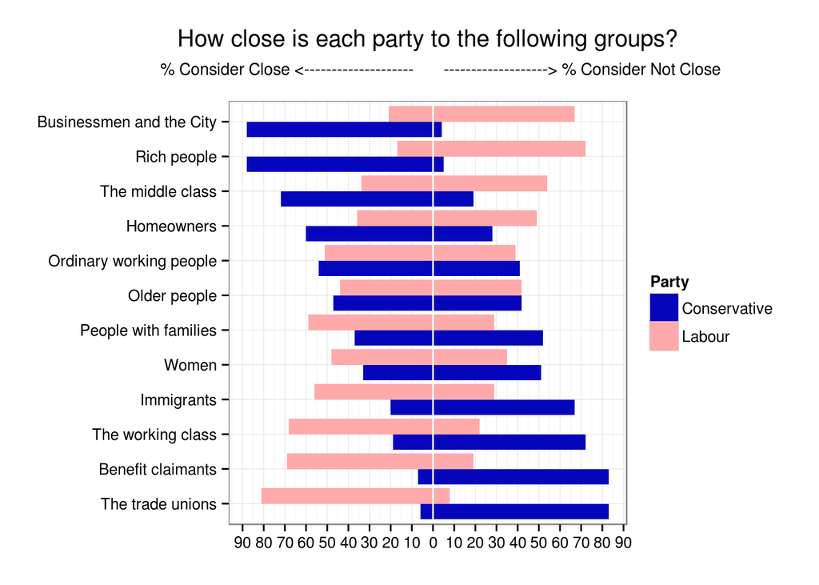

```r
reporturl <- "https://d25d2506sfb94s.cloudfront.net/cumulus_uploads/document/dmi10ux8ie/InternalResults_151002_PartyGroups_Website.pdf"

# Read the data in as a character vector of lines
raw <- loadfile(reporturl)

# Convert to a Dataframe
output <- raw2dataframe(raw)

# Tidy it up a bit
output <- tidydata(output)

# ... and plot!
plotme(output)
```